# ESM 206 Lab Week 3 Key

### Part 0: Setup and R Markdown basics

- Create a new R project
- Add two subfolders: data and src
- Download two data files from GauchoSpace: jornada_lizards.csv and lizard_abb.csv, and copy them into your project data folder
- Open a new R Markdown document in your project, delete all below the setup chunk
- Attach the necessary packages in the setup chunk (tidyverse, janitor, here, gapminder). Note, you probably need to install the `gapminder` package by running `install.packages("gapminder")` in the Console

### How to hide your code

```
## [1] "hello world"
```

### How to hide your output

```r
print("hello world")
```

### An overview of other options for showing or not showing code, output and messages

https://bookdown.org/yihui/rmarkdown-cookbook/hide-one.html

### Part 1: Tidying data continued

In this section, we’ll learn how to combine two data frames with `full_join()`, and to reshape with `pivot_longer()` and `pivot_wider()` to get data into tidy format.

A. Join lizard common names with lizard data

The following data are from Jornada Basin LTER:

- Title: Lizard pitfall trap data (LTER-II, LTER-III)
- URL: https://portal.edirepository.org/nis/mapbrowse?packageid=knb-lter-jrn.210007001.36
- Citation: Lightfoot, D. 2017. Lizard pitfall trap data (LTER-II, LTER-III) ver 36. Environmental Data Initiative. https://doi.org/10.6073/pasta/ff37b4cace16a9943575f3fd7067064e (Accessed 2020-07-05).
- Lizard code list from: https://jornada.nmsu.edu/content/lizard-code-list

Read in both lizards datasets:

- jornada_lizards.csv (pitfall trap data), which contains:
  - common name
  - site (site name)
  - sex (M = male, F = female, J = juvenile)
  - tail (B = broken, W = whole)
- lizard_abb.csv (lizard abbreviations & common names)

```r
# Read in lizards data
# Note: your path will differ depending on uyour project setup
lizard_names <- read_csv(here("data","lizard_abb.csv"))
lizard_traps <- read_csv(here("data","jornada_lizards.csv"))
```

Join together by the `common_name` variable with `full_join()`. See more information on `full_join()` - there are other options for more discriminating / excluding joins, but if you’re not sure how they work **FULL JOIN** and deal with filtering later!

```r
lizard_join <- lizard_traps %>%
  full_join(lizard_names)
```

Notice that it will first look for matching names, and join by those. But we don’t *have* to have matching names. For example, let’s make a version of lizard_traps that has common_name renamed as “lizard_name”:

```r
lizard_traps_rn <- lizard_traps %>%
  rename(lizard_name = common_name)
```

We can then specify which column to join by:

```r
lizard_join_2 <- lizard_traps_rn %>%
  full_join(lizard_names, by = c("lizard_name" = "common_name"))
```

Now let us count the number of occurrences using counts():

```r
tail_counts <- lizard_join %>%
  filter(common_name %in% c("Western Whiptail","Eastern Fence")) %>%
  count(common_name, tail)

# Or, using tools we already have:
tail_counts_2 <- lizard_join %>%
  filter(common_name %in% c("Western Whiptail", "Eastern Fence")) %>%
  group_by(common_name, tail) %>%
  summarize(count = n())
tail_counts
```

```
## # A tibble: 6 × 3
##   common_name      tail      n
##   <chr>            <chr> <int>
## 1 Eastern Fence    B         7
## 2 Eastern Fence    W        35
## 3 Eastern Fence    <NA>      1
## 4 Western Whiptail B        31
## 5 Western Whiptail W       183
## 6 Western Whiptail <NA>     13
```

```r
tail_counts_2
```

```
## # A tibble: 6 × 3
## # Groups:   common_name [2]
##   common_name      tail  count
##   <chr>            <chr> <int>
## 1 Eastern Fence    B         7
## 2 Eastern Fence    W        35
## 3 Eastern Fence    <NA>      1
## 4 Western Whiptail B        31
## 5 Western Whiptail W       183
## 6 Western Whiptail <NA>     13
```

B. `pivot_longer()` and `pivot_wider()`

Check out the gapminder data (reminder: why not put this `View(gapminder)` in your R Markdown code?)

Wrangle it a bit:

```r
n_am <- gapminder %>%
  filter(country %in% c("United States", "Canada", "Mexico")) %>%
  select(country, year, pop)
```

Note: these data are already in tidy format. So you probably wouldn’t want to do this:

Use `pivot_wider` to split years across multiple columns:

```r
n_am_wider <- n_am %>%
  pivot_wider(names_from = year,
              values_from = pop)
```

**Much more often** this wide format is the problem (e.g. year split up over multiple columns, but should be in a single column). We can use `pivot_longer()` to convert from wide-to-long format:

```r
n_am_longer <- n_am_wider %>%
  pivot_longer(cols = `1952`:`2007`,
               names_to = "year",
               values_to = "pop"
  ) %>%
  mutate(year = as.numeric(year))
```

Finally, let’s just do a quick ggplot reminder:

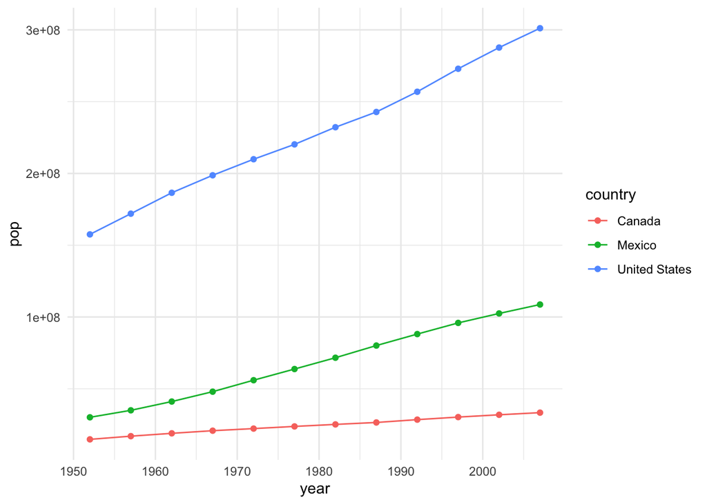

```r
ggplot(n_am_longer, aes(x = year, y = pop)) +
  geom_line(aes(color = country)) +
  geom_point(aes(color = country)) +
  theme_minimal()
```

### Part 2: Writing functions in R

What is a function? A function is a named bit of code that is meant to perform specific operations or tasks with user-defined arguments.

We’ve already been using tons of functions! All of our wrangling has been done with functions (`select()`, `filter()`, `mean()`, etc.) - but sometimes we might want to make our own.

To make our own function, we need to:

1. Name it
2. Tell it what the arguments are (choose useful names here, too!)
3. Specify the operation or tasks

The easiest way: write the equation like a normal human, then use Command + Option + X as a shortcut to put it into function notation!

```r
# Creating a distance function:
distance <- function(rate, time) {
  rate*time
}

# Then try it out with your own arguments added!
distance(rate = 60, time = 2)
```

```
## [1] 120
```

Example: the relationship between fish length (L) and weight (W) is estimated by:

$W=aL^b$

A summary of parameters for different fish can be found in Ogle, D. FishR Vignette - Fish Condition and Relative Weights (2013).

For red snapper, the parameters are estimated (from Diaz 2004) as:

- a = 0.00001
- b = 3.076

with length (L) in cm and weight (W) in kg.

Write a function for the red snapper relationship, then estimate the weight of a red snapper that is 42 cm long.

```r
fish_weight <- function(a, L, b) {
  a*(L^b)
}

fish_weight(a = 0.00001, L = 42, b = 3.076)
```

```
## [1] 0.9842713
```

```r
# 0.98 kg

# Note: you can also just add arguments in the correct ORDER without specifically naming them, but I prefer being explicit. For example:

fish_weight(0.00001, 42, 3.076)
```

```
## [1] 0.9842713
```

```r
# versus (same output):

fish_weight(a = 0.00001, L = 42, b = 3.076)
```

```
## [1] 0.9842713
```

Cool! Now you can make your own functions, with arguments that you name and specify!

## End Lab 3